# Assignment 4: Latin Hyper Cube and Sensitivity Analysis

Sarah Lam & Katheryn Moya & Sofia Urgoiti

2023-05-02

## A. Latin Hypercube Parameter Generation

Creating a matrix with random samples for the four parameters in our function to choose quantiles that will full sample parameter space.

```r
# Latin Hypercube generation of parameters
# set a random seed to make things 'random'
set.seed(1)

# which parameters
pnames = c("v", "height", "k_o", "k_d")

# how many parameters
npar =  length(pnames)
# how many samples
nsample = 100

parm_quant = randomLHS(nsample, npar)
colnames(parm_quant)=pnames
# choose distributions for parameters
# v - normally distributed with a mean of 250 cm/s with a standard deviation of 30 cm/s
# height - somewhere between 9.5 and 10.5 m (but any value in that range is equally likely)
# kd and k0 - normally distributed with standard deviation of 1% of their default values
# use random samples to pick the quantiles

parm = as.data.frame(matrix(nrow=nrow(parm_quant), ncol=ncol(parm_quant)))
colnames(parm) = pnames
# for each parameter pick samples
# I'm using several examples normal distribution (with 10% standard deviation) and uniform with +- 10%
# in reality I should pick distribution from knowledge about uncertainty in parameters
# to make it easy to change set standard deviation / range variation to a variable
pvar = .010

parm[,"v"] = qnorm(parm_quant[,"v"], mean=2.5, sd=0.3) #convert to meters/s for function
parm[,"height"] = qunif(parm_quant[,"height"], min=9.5, max=10.5)

# normal distribution 1% sd
parm[,"k_d"] = qnorm(parm_quant[,"k_d"], mean=0.7, sd=0.7*pvar)
parm[,"k_o"] = qnorm(parm_quant[,"k_o"], mean=0.1, sd=0.1*pvar)

head(parm) #creating a data frame of 100 potential parameter values based on the mean and sd of each parameter for sensitivity analysis
```

```
##          v    height        k_o       k_d
## 1 2.313051  9.651851 0.10087622 0.7003331
## 2 2.476994  9.827237 0.09939835 0.6905195
## 3 2.902433 10.169403 0.10103617 0.7029557
## 4 2.111180 10.077929 0.10222797 0.6972034
## 5 2.533871  9.813081 0.10054450 0.7013815
## 6 2.643967 10.425147 0.10043063 0.6930799
```

## B. Running Atmospheris Conductance Model

The model output is atmospheric conductance in mm/s for a given vegetation type (forest).

```r
source(here("R/Catm.R"))

catm <-  parm %>% pmap(Catm)

head(catm)
```

```
## [[1]]
## [1] 12.98143
##
## [[2]]
## [1] 13.91463
##
## [[3]]
## [1] 16.61861
##
## [[4]]
## [1] 12.09972
##
## [[5]]
## [1] 14.29068
##
## [[6]]
## [1] 15.24201
```

```r
#turn results into a data fram

catm_df <- do.call("rbind", catm)

catm_parm <- cbind(parm, catm_df)

nrow(catm_df)
```

```
## [1] 100
```

## C. Plotting Conductance Estimates & Parameter Uncertainty

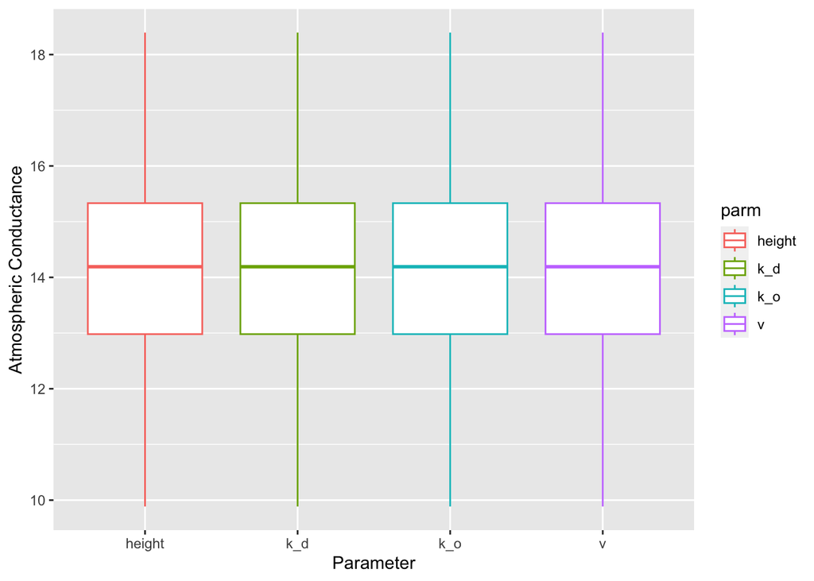

```r
#Sarah
# 1 density plot of boxplot to visualize all of the output
catm_long <-  catm_parm %>% pivot_longer(cols=c(v:k_d),
                    names_to='parm',
                    values_to='variance')
ggplot(catm_long, aes(x = parm, y = catm_df, col=parm)) +
  geom_boxplot() +
  labs(y="Atmospheric Conductance",
       x="Parameter")
```

```r
  #facet_wrap(~parm, scales="free")
```

Figure 1 uses a box plot to graphically shows the impact of uncertainty on our atmospheric conductance model across the four parameters in a given forest. Purely based on the box plot it is difficult to tell which parameter is driving the uncertainty in our output since the variation is similar across all parameters. To further investigate we will next graph the conductance against each parameter.

## D. Plotting Conductance Against Each Parameter

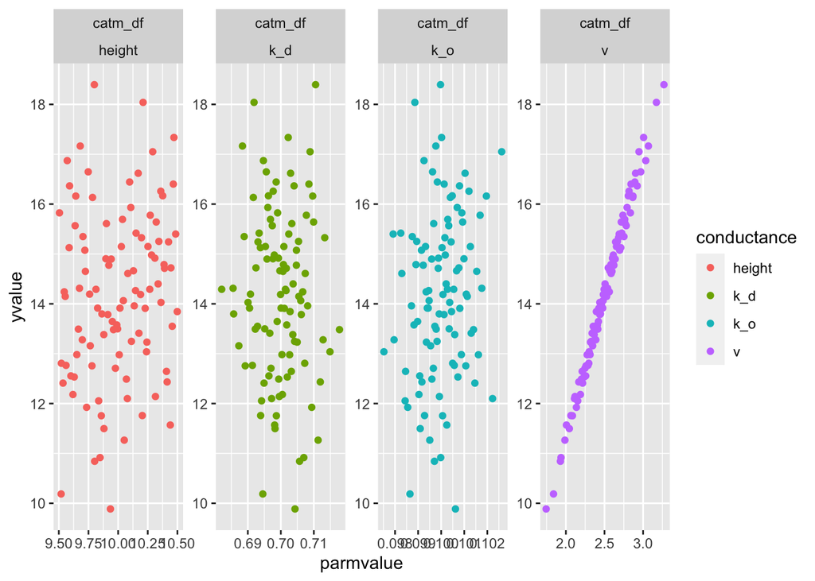

```r
#catm_parm is already a dataframe so we do not need to bind anything prior (...)
df = catm_parm %>% gather(catm_df, value = "yvalue", key = "conductance")
df2 = df %>% gather(-conductance, -yvalue, key = "parm", value = "parmvalue")

ggplot(df2, aes(parmvalue, yvalue,
col=conductance)) + geom_point(aes(colour=parm)) + facet_wrap(~conductance*parm, scales="free", ncol=4)
```

In Figure 2, atmospheric conductance uncertainty is plotted against each of the 4 parameters. The windspeed parameter (v) presents a clear monotonic and positive relationship, with data points forming a straight line. This indicates that windspeed is an important parameter in determining atmospheric conductance, relative to other parameters such as height, or k0 and kd. Therefore, to reduce uncertainty in atmospheric conductance estimates, a greater focus should be placed in increasing the accuracy of windspeed measurements which are then input in models.

## E. Partial Rank Correlation Coefficients

```r
#Katheryn
# combine parameter sets with output

sen_result <- pcc(parm, catm_df)

# see coefficients

sen_result
```

```
##
## Call:
## pcc(X = parm, y = catm_df)
##
## Partial Correlation Coefficients (PCC):
##         original
## v      0.9999300
## height 0.9916891
## k_o    0.9372664
## k_d    0.1638221
```

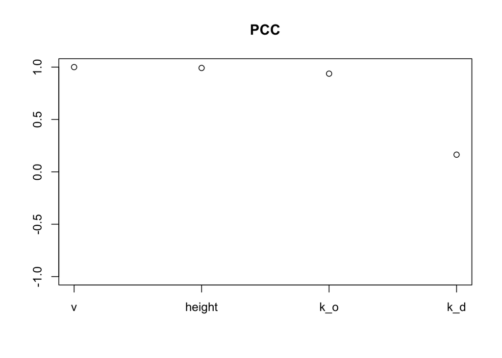

```r
# efficiently plot them

plot(sen_result)
```

```r
# try again using rank coefficients

sen_result_rank = pcc(parm, catm_df, rank=TRUE)
sen_result_rank
```

```
##
## Call:
## pcc(X = parm, y = catm_df, rank = TRUE)
##
## Partial Rank Correlation Coefficients (PRCC):
##          original
## v       0.9988798
## height  0.8657835
## k_o     0.4100546
## k_d    -0.1835439
```

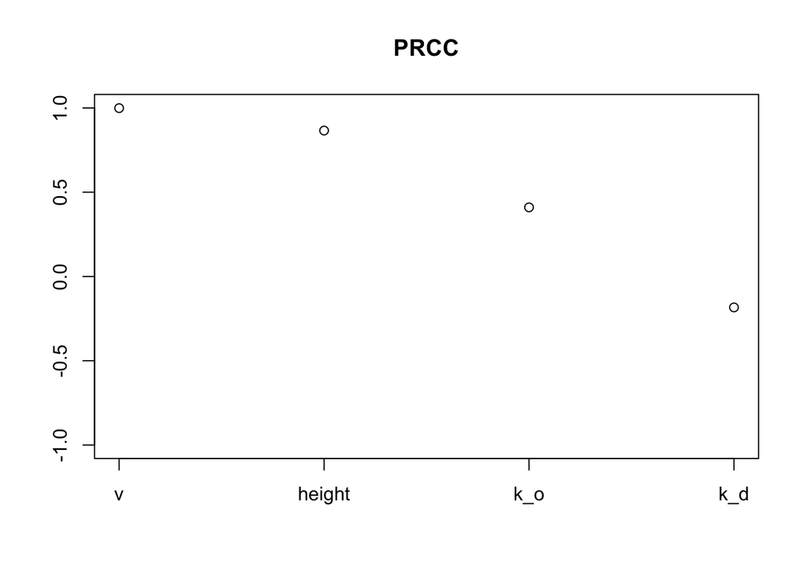

```r
plot(sen_result_rank)
```

```r
# R sometimes returns complex lists - to see what you have
str(sen_result)
```

```
## List of 7
##  $ X    :'data.frame':   100 obs. of  4 variables:
##   ..$ v     : num [1:100] 2.31 2.48 2.9 2.11 2.53 ...
##   ..$ height: num [1:100] 9.65 9.83 10.17 10.08 9.81 ...
##   ..$ k_o   : num [1:100] 0.1009 0.0994 0.101 0.1022 0.1005 ...
##   ..$ k_d   : num [1:100] 0.7 0.691 0.703 0.697 0.701 ...
##  $ y    : num [1:100, 1] 13 13.9 16.6 12.1 14.3 ...
##  $ rank : logi FALSE
##  $ nboot: num 0
##  $ conf : num 0.95
##  $ call : language pcc(X = parm, y = catm_df)
##  $ PCC  :'data.frame':   4 obs. of  1 variable:
##   ..$ original: num [1:4] 1 0.992 0.937 0.164
##  - attr(*, "class")= chr "pcc"
```

```r
sen_result$PCC
```

```
##         original
## v      0.9999300
## height 0.9916891
## k_o    0.9372664
## k_d    0.1638221
```

From the PCC we can tell that the parameter with the highest correlation with model output is indeed windspeed (v).

## F. Discussion

Our results tell us that atmospheric conductance in a given forest is most influenced by windspeed, followed by vegetation height, and roughness, and is the least impacted by the zero plane displacement. This suggests that, in order to reduce uncertainty in aerodynamic conductance estimates, you should attempt to get the best parameter estimates for windspeed and height in a given forest. In the context of plant sensitivity ti climate change, this tells us that plant water may change as a result of chagnes in highly correlated variable such as windespeed in a given forest because plant water use is highly related to atmospheric conduction. Plant evapotranspiration is more likely to be effected by changes in windspeeds as this parameter has the greatest influence on atmospheric conductance.